# QC of PLC and MSC EPIC Methlyation

### Quality Control (preform on the tissues together)

#### Outlier Identification

Outliers will be identified as samples that are under the 1st percentile for median methlyated intensity or greater than the 99th percentile for the fraction of failed positions. If a sample is identified as an outlier in the methylated median intensity and fraction of failed positions then it was removed.

#### Remove Samples with Low Median Intensity

```r
mset <- preprocessRaw(rgSet = rgSet)
qc   <- getQC(mset)

invisible(qcReport(rgSet, sampNames=colnames(rgSet), pdf=paste0(dir_ext, "qcReport.pdf")))
```

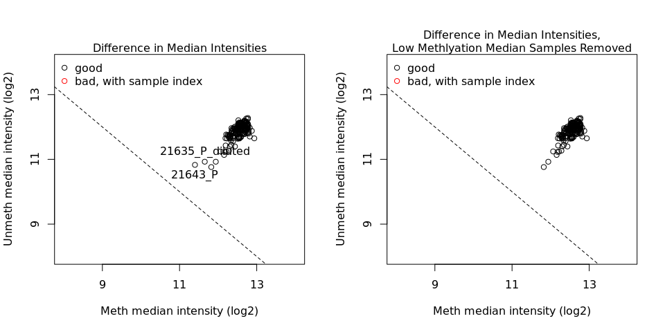

```r
badid <- rownames(qc)[which(qc[,1] < quantile(qc[,1], 0.01))]
write.table(badid, file=paste0(dir_ext, "badid.txt"), quote=F, row.names=F, col.names=F)

jpeg(paste0(fig_ext, "qcplot_1.jpg"))
plotQC(qc)
text(qc[which(rownames(qc) %in% badid[1]),1], qc[which(rownames(qc) %in% badid[1]),2], labels=badid[1], pos = 1)
text(qc[which(rownames(qc) %in% badid[2]),1], qc[which(rownames(qc) %in% badid[2]),2], labels=badid[2], pos = 3)
mtext("Difference in Median Intensities", side = 3)
invisible(dev.off())

## Plot histogram of differences in median intensities, samp rm
jpeg(paste0(fig_ext, "qcplot_1_rm.jpg"))
plotQC(qc[which(rownames(qc) %notin% badid), ])
mtext("Difference in Median Intensities,\nLow Methlyation Median Samples Removed", side = 3)
invisible(dev.off())

par(mfrow = c(1,2))
plotQC(qc)
text(qc[which(rownames(qc) %in% badid[1]),1], qc[which(rownames(qc) %in% badid[1]),2], labels=badid[1], pos = 1)
text(qc[which(rownames(qc) %in% badid[2]),1], qc[which(rownames(qc) %in% badid[2]),2], labels=badid[2], pos = 3)
mtext("Difference in Median Intensities", side = 3)
plotQC(qc[which(rownames(qc) %notin% badid), ])
mtext("Difference in Median Intensities,\nLow Methlyation Median Samples Removed", side = 3)
```

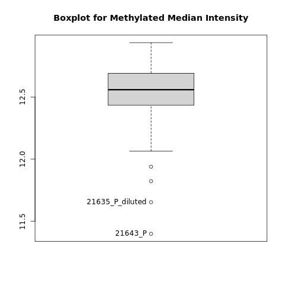

```r
jpeg(paste0(fig_ext, "qcplot_boxplot.jpg"))
boxplot(qc$mMed,  main="Boxplot for Methylated Median Intensity")
text(qc[which(rownames(qc) %in% badid[1]),1], labels=badid[1], pos = 2)
text(qc[which(rownames(qc) %in% badid[2]),1], labels=badid[2], pos = 2)
invisible(dev.off())

knitr::include_graphics(paste0(fig_ext, "qcplot_boxplot.jpg"))
```

```r
message("There are ", length(badid), " samples with low median intensity (below the 1st percentile). The samples are ", paste(badid, collaspe = " and "), ". 21635_P_diluted is known to be a diluted sample and will be removed later with the other diluted samples.")
```

```
## There are 2 samples with low median intensity (below the 1st percentile). The samples are 21643_P  and 21635_P_diluted  and . 21635_P_diluted is known to be a diluted sample and will be removed later with the other diluted samples.
```

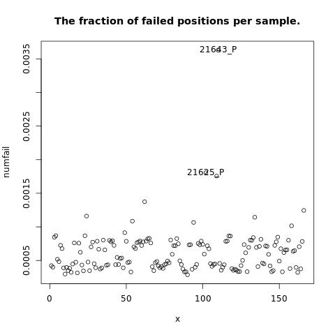

```r
# Remove Probes with Detection p-value > 0.01 in more than 10% Samples
detP <- detectionP(rgSet = rgSet)
detPcut <- 0.01

failed <- detP > detPcut
numfail <- colMeans(failed)
x <- seq(1, length(numfail), 1)

badPosition <- names(numfail[which(numfail > quantile(numfail, 0.99))])
## Plot fraction of failed positions per sample
jpeg(paste0(fig_ext, "failed_pos.jpg"))
base::plot(x, numfail, main="The fraction of failed positions per sample.")
text(x[which(numfail > quantile(numfail, 0.99))], numfail[which(numfail > quantile(numfail, 0.99))], labels=names(numfail[which(numfail > quantile(numfail, 0.99))]))
invisible(dev.off())

knitr::include_graphics(paste0(fig_ext, 'failed_pos.jpg'))
```

```r
badFailPerSample <- numfail > 0.003
mset00 <- mset[,!badFailPerSample]

x[numfail==max(numfail)]
```

```
## [1] 110
```

```r
removeDetP <- 0.1
badProbes <- rowMeans(failed) > removeDetP
badProbeNames1 <- names(badProbes)

message("There are ", prettyNum(length(badProbes), big.mark = ","), " probes with a high percent of failed sample.")
```

[output not shown]

```r
message("There are ", prettyNum(length(badPosition), big.mark = ","), " samples with a high percent of failed probes (above the 99th percentile). The samples are ", paste0(badid, collaspe = " and "), ". Given that 21643_P was identified as an outlier for median methlyated intensity and fraction of failed positions. This sample will be removed.")
```

[output not shown]

```r
mset01 <- mset00[!badProbes,]

# Remove Samples with Detection p-value > 0.01 in more than 1% of Probes
samps_numfail <- rowMeans(failed)
x1 <- seq(1, length(samps_numfail), 1)

## Plot fraction of failed samples per probe
jpeg(paste0(fig_ext, "failed_samps.jpg"))
base::plot(x1, samps_numfail, main="The fraction of failed positions per probe")
invisible(dev.off())

x1[samps_numfail==max(samps_numfail)]
```

```
## [1] 447043
```

```r
samp_removeDetP <- 0.01
badSamps <- colMeans(failed) > removeDetP
mset02 <- mset01[!badSamps,]

message("There are ", prettyNum(length(badSamps[which(badSamps == TRUE)]), big.mark = ","), " samples who had a detection p-value > 0.01 in more than 1% of probes.")
```

```
## There are 0 samples who had a detection p-value > 0.01 in more than 1% of probes.
```

```r
# Remove Probes with a Bead Count <3 in at least 5% of Samples
beadCutoff = 0.05
bc <- beadcount(rgSet)

bc2 = bc[rowSums(is.na(bc)) < beadCutoff * (ncol(bc)), ]
badProbeNames2 <- row.names(bc[rowSums(is.na(bc)) >= beadCutoff*(ncol(bc)), ])
mset03 = mset02[featureNames(mset02) %in% row.names(bc2), ]

message("There are ", prettyNum(dim(mset02)[1] - dim(mset03)[1], big.mark = ","), " probes with a bead count < 3 in more then 5% of the samples. These probes were removed.")
```

```
## There are 9,438 probes with a bead count < 3 in more then 5% of the samples. These probes were removed.
```

```r
# Check non-CG Probes
mset.cg <- dropMethylationLoci(mset03, dropCH=T)

message("There are ", prettyNum(dim(mset03)[1] - dim(mset.cg)[1], big.mark = ",")," non-CpG probes. They were kept in the data set.")
```

```
## There are 2,928 non-CpG probes. They were kept in the data set.
```

```r
# Map to the Genome
gset <- mapToGenome(mset03)

annotation  <- getAnnotation(gset, dropNonMapping=F)
annotation2 <- getAnnotation(gset, dropNonMapping=T)

message("There are ",  prettyNum(dim(annotation)[1] - dim(annotation2)[1], big.mark = ","), " non-mapping probes.")
```

```
## There are 0 non-mapping probes.
```

```r
# ID Probes with SNPS
snps <- getSnpInfo(gset)
gset <- addSnpInfo(gset)

gset02 <- dropLociWithSnps(gset, snps=c("SBE", "CpG"), maf=0)
badProbeNames3 <- featureNames(gset)[!featureNames(gset) %in% featureNames(gset02)]

message("There are ", prettyNum(dim(gset)[1] - dim(gset02)[1], big.mark = ","), " probes had SNPs at the CpG interrogation and/or at the single nucleotide extension for any minor allele frequency. These probes were removed.")
```

```
## There are 29,809 probes had SNPs at the CpG interrogation and/or at the single nucleotide extension for any minor allele frequency. These probes were removed.
```

```r
# remove cross-reactive probes
gset03 <- maxprobes::dropXreactiveLoci(gset02)

message("There are ", prettyNum(dim(gset02)[1] - dim(gset03)[1], big.mark = ","), " cross reactive probes.")
```

```
## There are 40,655 cross reactive probes.
```

```r
# create the final gset and mset
gset_qc <- gset03
mset_qc <- mset03
```

##### Density Plots of Raw Beta and M Values

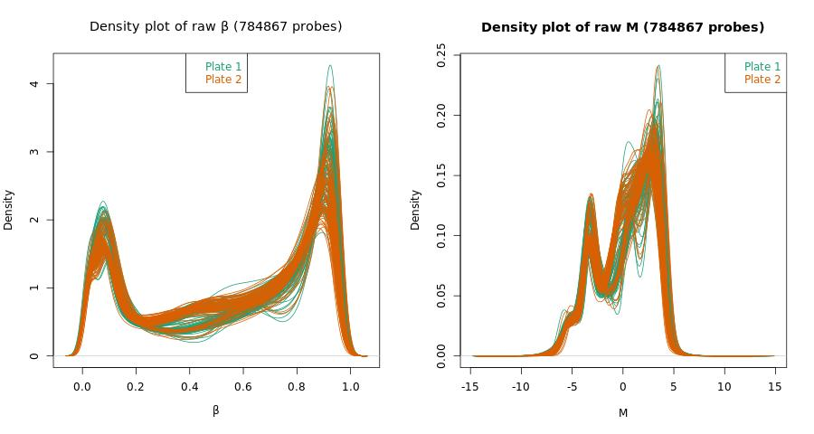

```r
beta.raw <- getBeta(gset_qc)
M.raw    <- getM(gset_qc)

# Plot density of raw beta
totalProbes <- dim(beta.raw)[1]
main1 <- bquote("Density plot of raw"~beta~"("*.(totalProbes)~"probes)")
main2 <- paste("Density plot of raw M (", totalProbes, " probes)", sep = "")
pal = brewer.pal(8, "Dark2")

jpeg(paste0(fig_ext, "rawbeta_m.jpg"), width = 900)
par(mfrow = c(1,2))
densityPlot(beta.raw, sampGroups = pData(gset_qc)$Sample_Plate,
            main = main1, xlab = expression(beta), legend=F)
legend("top", legend = levels(as.factor(pData(gset_qc)$Sample_Plate)), text.col = pal)
densityPlot(M.raw, sampGroups = pData(gset_qc)$Sample_Plate,
            main = main2, xlab = "M", legend=F)
legend("topright", legend = levels(as.factor(pData(gset_qc)$Sample_Plate)), text.col =pal)
invisible(dev.off())

knitr::include_graphics(paste0(fig_ext, 'rawbeta_m.jpg'))
```

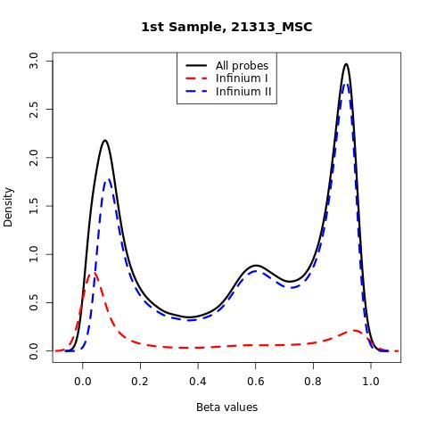

```r
snames <- sampleNames(gset_qc)
jpeg(paste0(fig_ext, "samp1.jpg"))
main3 <- paste("1st Sample, ", snames[1], sep='')
plotBetasByType(mset_qc[,1], main=main3)
invisible(dev.off())

knitr::include_graphics(paste0(fig_ext, 'samp1.jpg'))
```

#### Check for Sex Discrepancies and Remove Diluted Samples

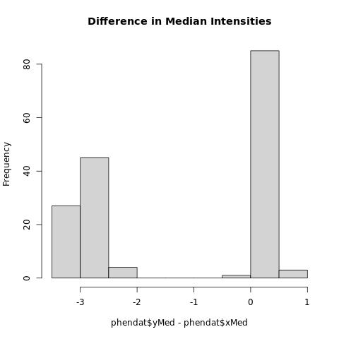

```r
## Get median intensities for X and Y chroms
gset_sex <- getSex(gset_qc, cutoff = -1)
## Add these columns to the phenotype data for the gset
pData(gset_qc) <- cbind(pData(gset_qc), gset_sex)
phendat <- pData(gset_qc)

jpeg(paste0(fig_ext, "differencesMedian_sex.jpg"))
hist(phendat$yMed - phendat$xMed, main = "Difference in Median Intensities")
invisible(dev.off())

knitr::include_graphics(paste0(fig_ext, "differencesMedian_sex.jpg"))
```

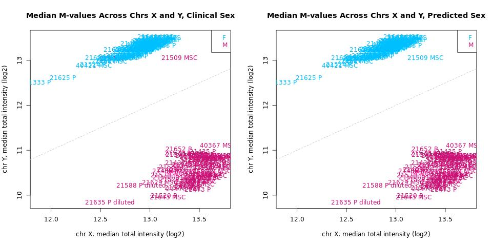

```r
jpeg(paste0(fig_ext, "clinical_predictedSex.jpg"), width = 960)
par(mfrow=c(1,2))
plot(as.numeric(phendat$xMed), as.numeric(phendat$yMed), type="n",
     xlab="chr X, median total intensity (log2)",
     ylab="chr Y, median total intensity (log2)",
     main="Median M-values Across Chrs X and Y, Clinical Sex")
text(as.numeric(phendat$xMed), as.numeric(phendat$yMed),
     phendat$Sample_Name,
     col = ifelse(phendat$infant_sex=="M", "deepskyblue", "deeppink3"))
legend("topright", legend = levels(as.factor(phendat$infant_sex)), text.col = c("deepskyblue", "deeppink3"))
abline(a=-1, b=1, col="gray", lty=2)
plot(as.numeric(phendat$xMed), as.numeric(phendat$yMed), type="n",
     xlab="chr X, median total intensity (log2)",
     ylab="chr Y, median total intensity (log2)",
     main="Median M-values Across Chrs X and Y, Predicted Sex")
text(as.numeric(phendat$xMed), as.numeric(phendat$yMed),
     phendat$Sample_Name,
     col = ifelse(phendat$predictedSex=="M", "deepskyblue", "deeppink3"))
legend("topright", legend = levels(as.factor(phendat$predictedSex)), text.col = c("deepskyblue", "deeppink3"))
abline(a=-1, b=1, col="gray", lty=2)
invisible(dev.off())

knitr::include_graphics(paste0(fig_ext, 'clinical_predictedSex.jpg'))
```

```r
##Compare predicted sex with clinical sex data
badsex <- phendat[which(phendat$predictedSex != phendat$infant_sex), "Sample_Name"] # n = 2
write.csv(badsex, file=paste0(dir_ext, "badsex.txt"))

message("There were ", prettyNum(length(badsex), big.mark = ","), " samples where predicted sex did not match clinical sex (", paste(badsex, collapse = ", "), "). These samples were removed.")
```

```
## There were 2 samples where predicted sex did not match clinical sex (21379 P, 21509 MSC). These samples were removed.
```

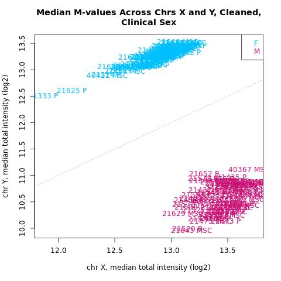

```r
# remove the mismatched sex and diluted samples
pheno_clean <- phendat[which(phendat$Sample_Name %notin% c(badsex, "21588 P diluted", "21635 P diluted")), ]
gset_clean  <- gset_qc[, gset_qc$Sample_Name %notin% c(badsex, "21588 P diluted", "21635 P diluted")]

## plotSex
# cleaned data
jpeg(paste0(fig_ext, "sex_intensity_clean.jpg"))
plot(as.numeric(pheno_clean$xMed), as.numeric(pheno_clean$yMed), type="n",
     xlab="chr X, median total intensity (log2)",
     ylab="chr Y, median total intensity (log2)",
     main="Median M-values Across Chrs X and Y, Cleaned,\nClinical Sex")
text(as.numeric(pheno_clean$xMed), as.numeric(pheno_clean$yMed),
     pheno_clean$Sample_Name,
     col = ifelse(pheno_clean$infant_sex=="M", "deepskyblue", "deeppink3"))
abline(a=-1, b=1, col="gray", lty=2)
legend("topright", legend = levels(as.factor(phendat$predictedSex)), text.col = c("deepskyblue", "deeppink3"))
invisible(dev.off())

knitr::include_graphics(paste0(fig_ext, 'sex_intensity_clean.jpg'))
```

##### Seperating the 2 datasets

```r
gset_PLC <- gset_clean[,gset_clean$tissue %in% "P"]
gset_MSC <- gset_clean[,gset_clean$tissue %in% "MSC"]

gset_PLC
```

```
## class: GenomicMethylSet
## dim: 784867 100
## metadata(0):
## assays(2): Meth Unmeth
## rownames(784867): cg26928153 cg16269199 ... cg21106100 cg08265308
## rowData names(6): Probe_rs Probe_maf ... SBE_rs SBE_maf
## colnames(100): 21313_P 21365_P ... 40837_P 21644_P
## colData names(20): Sample_Name Sample_Well ... yMed predictedSex
## Annotation
##   array: IlluminaHumanMethylationEPIC
##   annotation: ilm10b4.hg19
## Preprocessing
##   Method: Raw (no normalization or bg correction)
##   minfi version: 1.34.0
##   Manifest version: 0.3.0
```

```r
gset_MSC
```

```
## class: GenomicMethylSet
## dim: 784867 61
## metadata(0):
## assays(2): Meth Unmeth
## rownames(784867): cg26928153 cg16269199 ... cg21106100 cg08265308
## rowData names(6): Probe_rs Probe_maf ... SBE_rs SBE_maf
## colnames(61): 21313_MSC 21365_MSC ... 40604_MSC 40756_MSC
## colData names(20): Sample_Name Sample_Well ... yMed predictedSex
## Annotation
##   array: IlluminaHumanMethylationEPIC
##   annotation: ilm10b4.hg19
## Preprocessing
##   Method: Raw (no normalization or bg correction)
##   minfi version: 1.34.0
##   Manifest version: 0.3.0
```

```r
dim(gset_qc)[1]  == dim(gset_PLC)[1] #  TRUE
```

```
## [1] TRUE
```

```r
dim(gset_PLC)[1] == dim(gset_MSC)[1] #  TRUE
```

```
## [1] TRUE
```

##### Find cell composition of Placenta Data

```r
# function from cran page of minfi
projectCellType <- function(Y, coefCellType, contrastCellType = NULL,
                            nonnegative = TRUE, lessThanOne = FALSE) {
    if (is.null(contrastCellType)) {
        Xmat <- coefCellType
    } else {
        Xmat <- tcrossprod(coefCellType, contrastCellType)
    }

    nCol <- dim(Xmat)[2]
    if (nCol == 2) {
        Dmat <- crossprod(Xmat)
        mixCoef <- t(
            apply(Y, 2, function(x) solve(Dmat, crossprod(Xmat, x))))
        colnames(mixCoef) <- colnames(Xmat)
        return(mixCoef)
    } else {
        nSubj <- dim(Y)[2]

        mixCoef <- matrix(0, nSubj, nCol)
        rownames(mixCoef) <- colnames(Y)
        colnames(mixCoef) <- colnames(Xmat)

        if (nonnegative) {
            if (lessThanOne) {
                Amat <- cbind(rep(-1, nCol), diag(nCol))
                b0vec <- c(-1, rep(0, nCol))
            } else {
                Amat <- diag(nCol)
                b0vec <- rep(0, nCol)
            }
            for (i in seq_len(nSubj)) {
                obs <- which(!is.na(Y[,i]))
                Dmat <- crossprod(Xmat[obs,])
                mixCoef[i,] <- solve.QP(
                    Dmat = Dmat,
                    dvec = crossprod(Xmat[obs,], Y[obs,i]),
                    Amat = Amat,
                    bvec = b0vec)$sol
            }
        } else {
            for (i in seq_len(nSubj)) {
                obs <- which(!is.na(Y[,i]))
                Dmat <- crossprod(Xmat[obs,])
                mixCoef[i,] <- solve(Dmat, t(Xmat[obs,]) %*% Y[obs,i])
            }
        }
        mixCoef
    }
}

beta_PLC <- getBeta(gset_PLC)

cell.counts_PLC <- projectCellType(beta_PLC[which(rownames(beta_PLC) %in% rownames(plCellCpGsThird)),], plCellCpGsThird, lessThanOne = FALSE)

save(cell.counts_PLC, file = paste0(dir_ext, "cellCompositionPLC.rData"))
```

### Qaurtile Normalization

```r
quant_norm <- function(gset_clean, tissue){
  gset_norm <- preprocessQuantile(gset_clean, removeBadSamples = T)
  beta_norm <- getBeta(gset_norm)
  colnames(beta_norm) <- sampleNames(gset_clean)
  m_norm <- getM(gset_norm)
  colnames(m_norm) <- sampleNames(gset_clean)

  totalProbes <- dim(beta_norm)[1]

  # Plot density of norm beta
  jpeg(paste0(fig_ext, "normBeta_", tissue, ".jpg"))
  main1 <- bquote("Density plot of Normalized "~beta~"("*.(totalProbes)~"probes)")
  pal = brewer.pal(8, "Dark2")
  densityPlot(beta_norm, sampGroups = pData(gset_norm)$Sample_Plate,
              main = main1, xlab = expression(beta), legend=F)
  legend("top", legend = levels(as.factor(pData(gset_norm)$Sample_Plate)), text.col = pal)
  invisible(dev.off())

  jpeg(paste0(fig_ext, "mds_infantSex_", tissue, ".jpg"), width = 960)
  par(cex = 0.8, mfrow = c(1,2))
  mdsPlot(beta_norm, numPositions = 1000, sampGroups = pData(gset_norm)$infant_sex,
          sampNames = pData(gset_norm)$Sample_Name, main = "Whole Genome: MDS Infant Sex, beta")
  mdsPlot(m_norm, numPositions = 1000, sampGroups = pData(gset_norm)$infant_sex,
          sampNames = pData(gset_norm)$Sample_Name, main = "Whole Genome: MDS Infant Sex, m-value")
  invisible(dev.off())

  jpeg(paste0(fig_ext, "mds_samplePlate_", tissue, ".jpg"), width = 960)
  par(cex = 0.8, mfrow = c(1,2))
  mdsPlot(beta_norm, numPositions = 1000, sampGroups = pData(gset_norm)$Sample_Plate,
          sampNames = pData(gset_norm)$Sample_Name, main = "Whole Genome: MDS Sample Plate, beta")
  mdsPlot(m_norm, numPositions = 1000, sampGroups = pData(gset_norm)$Sample_Plate,
          sampNames = pData(gset_norm)$Sample_Name, main = "Whole Genome: MDS Sample Plate, m-value")
  invisible(dev.off())

  jpeg(paste0(fig_ext, "mds_array_", tissue, ".jpg"), width = 960)
  par(cex = 0.8, mfrow = c(1,2))
  mdsPlot(beta_norm, numPositions = 1000, sampGroups = pData(gset_norm)$Array,
          sampNames = pData(gset_norm)$Sample_Name, main = "Whole Genome: MDS Array, beta")
  mdsPlot(m_norm, numPositions = 1000, sampGroups = pData(gset_norm)$Array,
          sampNames = pData(gset_norm)$Sample_Name, main = "Whole Genome: MDS Array, m-value")
  invisible(dev.off())

    # look at the autosomes
  annotation <- getAnnotation(gset_norm)
  autosomes <- annotation[!annotation$chr %in% c("chrX", "chrY"),]
  gset_norm_auto <- gset_norm[featureNames(gset_norm) %in% row.names(autosomes),]
  beta_norm_auto <- getBeta(gset_norm_auto)
  m_norm_auto    <- getM(gset_norm_auto)
  colnames(m_norm_auto) <- sampleNames(gset_norm)
  totalProbes2 <- dim(beta_norm_auto)[1]

  jpeg(paste0(fig_ext, "normBeta_auto_", tissue, ".jpg"))
  main1 <- bquote("Autosomes: Density plot of Normalized"~beta~"("*.(totalProbes2)~"probes)")
  pal = brewer.pal(8, "Dark2")
  densityPlot(beta_norm_auto, sampGroups = pData(gset_norm_auto)$Sample_Plate,
              main = main1, xlab = expression(beta), legend=F)
  legend("top", legend = levels(as.factor(pData(gset_norm_auto)$Sample_Plate)), text.col = pal)
  invisible(dev.off())

  jpeg(paste0(fig_ext, "mds_infantSex_auto_", tissue, ".jpg"), width = 960)
  par(cex = 0.8, mfrow = c(1,2))
  mdsPlot(beta_norm_auto, numPositions = 1000, sampGroups = pData(gset_norm_auto)$infant_sex,
          sampNames = pData(gset_norm_auto)$Sample_Name, main = "Autosomes: MDS Infant Sex, beta")
  mdsPlot(m_norm_auto, numPositions = 1000, sampGroups = pData(gset_norm_auto)$infant_sex,
          sampNames = pData(gset_norm_auto)$Sample_Name, main = "Autosomes: MDS Infant Sex, m-value")
  invisible(dev.off())

  jpeg(paste0(fig_ext, "mds_samplePlate_auto_", tissue, ".jpg"), width = 960)
  par(cex = 0.8, mfrow = c(1,2))
  mdsPlot(beta_norm_auto, numPositions = 1000, sampGroups = pData(gset_norm_auto)$Sample_Plate,
          sampNames = pData(gset_norm_auto)$Sample_Name, main = "Autosomes: MDS Sample Plate, beta")
  mdsPlot(m_norm_auto, numPositions = 1000, sampGroups = pData(gset_norm_auto)$Sample_Plate,
          sampNames = pData(gset_norm_auto)$Sample_Name, main = "Autosomes: MDS Sample Plate, m-value")
  invisible(dev.off())

  jpeg(paste0(fig_ext, "mds_array_auto_", tissue, ".jpg"), width = 960)
  par(cex = 0.8, mfrow = c(1,2))
  mdsPlot(beta_norm_auto, numPositions = 1000, sampGroups = pData(gset_norm)$Array,
          sampNames = pData(gset_norm_auto)$Sample_Name, main = "Autosomes: MDS Array, beta")
  mdsPlot(m_norm_auto, numPositions = 1000, sampGroups = pData(gset_norm)$Array,
          sampNames = pData(gset_norm_auto)$Sample_Name, main = "Autosomes: MDS Array, m-value")
  invisible(dev.off())

  out <- list(gset_norm, beta_norm, m_norm, gset_norm_auto, beta_norm_auto, m_norm_auto)
  names(out) <- c("gset", "beta", "mset", "auto_gset", "auto_beta", "auto_mset")

  return(out)
}

norm_PLC <- quant_norm(gset_PLC, "PLC")
norm_MSC <- quant_norm(gset_MSC, "MSC")

#min(norm_PLC$beta)
#max(norm_PLC$beta)

#table(getAnnotation(norm_PLC$gset)$chr)
#table(getAnnotation(norm_MSC$gset)$chr)

#table(pData(norm_PLC$gset)$infant_sex, pData(norm_PLC$gset)$predictedSex)
#table(pData(norm_MSC$gset)$infant_sex, pData(norm_MSC$gset)$predictedSex)
```

#### Placenta

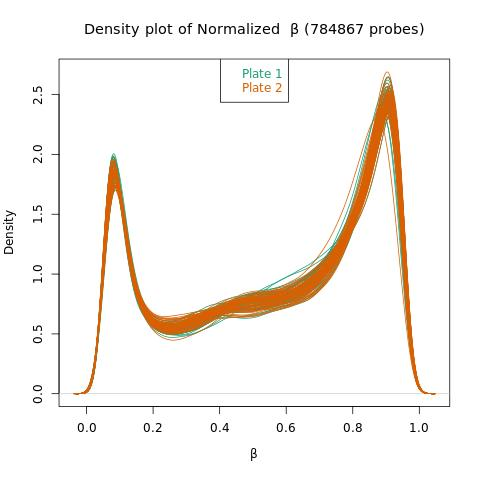

```r
knitr::include_graphics(paste0(fig_ext, 'normBeta_PLC.jpg'))
```

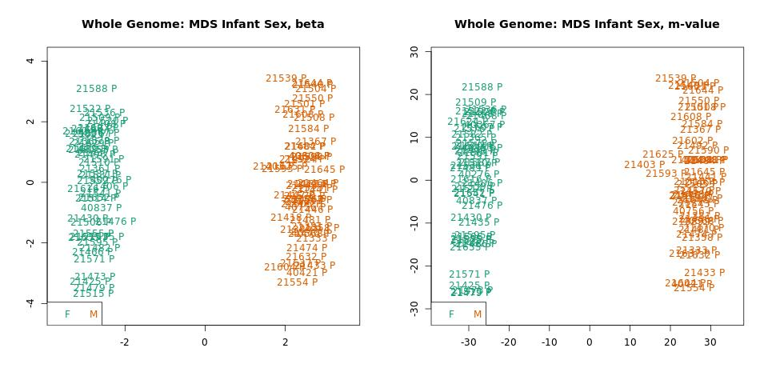

```r
knitr::include_graphics(paste0(fig_ext, 'mds_infantSex_PLC.jpg'))
```

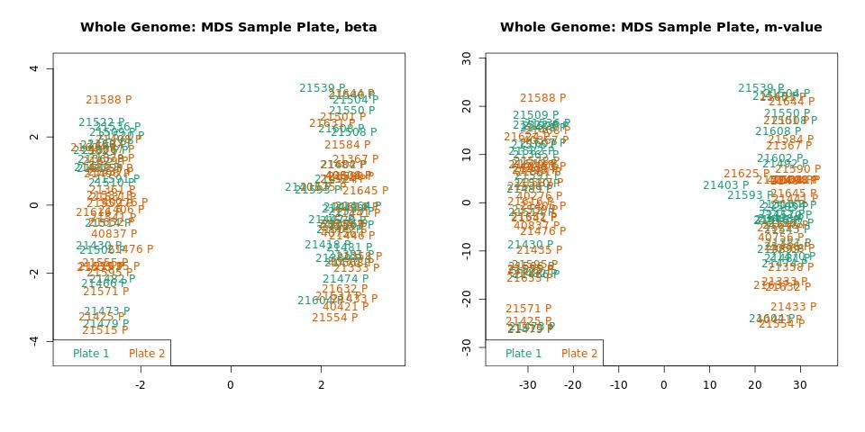

```r
knitr::include_graphics(paste0(fig_ext, 'mds_samplePlate_PLC.jpg'))
```

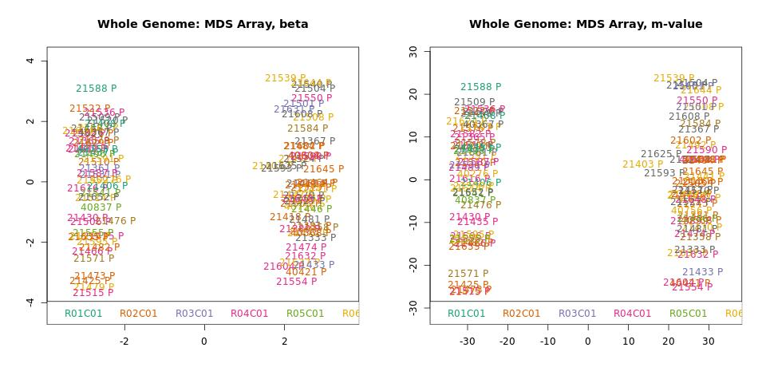

```r
knitr::include_graphics(paste0(fig_ext, 'mds_array_PLC.jpg'))
```

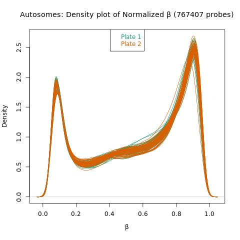

```r
knitr::include_graphics(paste0(fig_ext, 'normBeta_auto_PLC.jpg'))
```

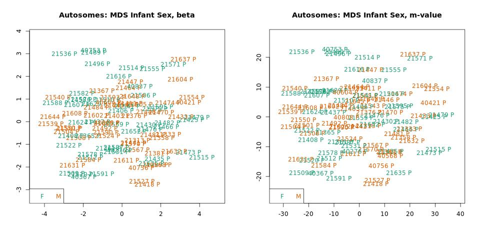

```r
knitr::include_graphics(paste0(fig_ext, 'mds_infantSex_auto_PLC.jpg'))
```

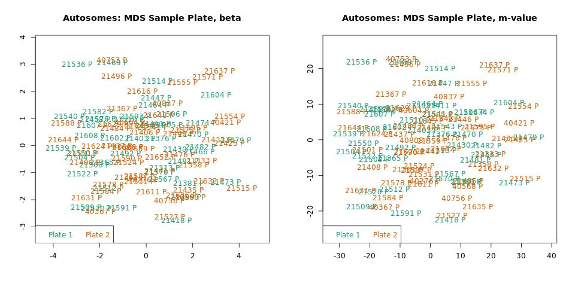

```r
knitr::include_graphics(paste0(fig_ext, 'mds_samplePlate_auto_PLC.jpg'))
```

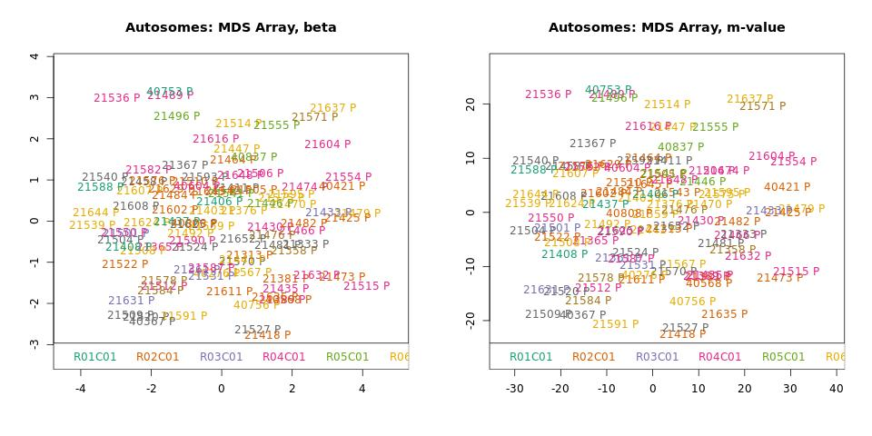

```r
knitr::include_graphics(paste0(fig_ext, 'mds_array_auto_PLC.jpg'))
```

#### MSC

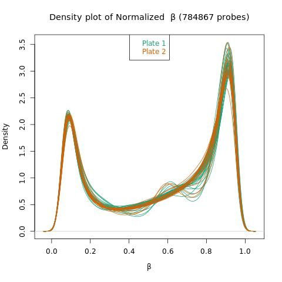

```r
knitr::include_graphics(paste0(fig_ext, 'normBeta_MSC.jpg'))
```

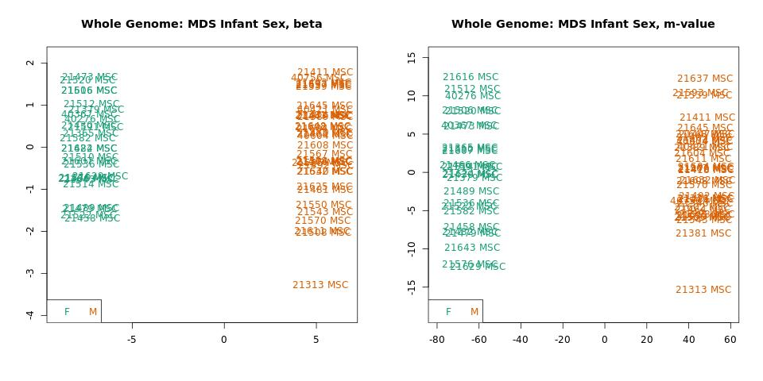

```r
knitr::include_graphics(paste0(fig_ext, 'mds_infantSex_MSC.jpg'))
```

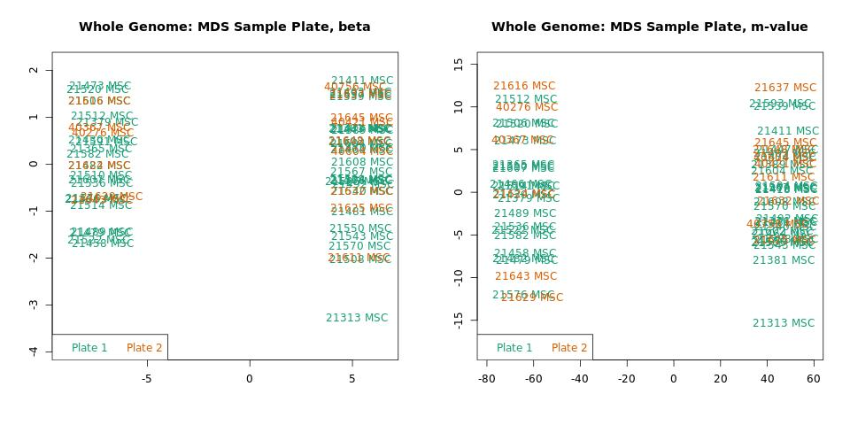

```r
knitr::include_graphics(paste0(fig_ext, 'mds_samplePlate_MSC.jpg'))
```

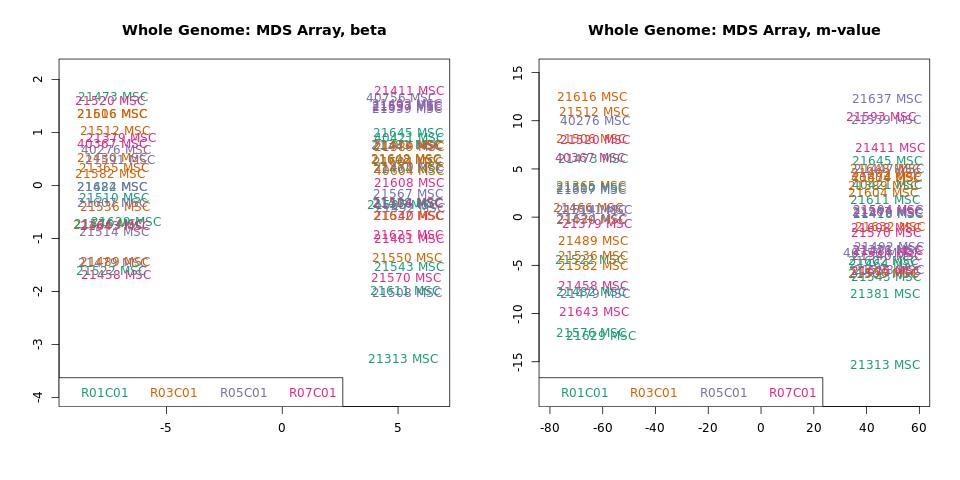

```r
knitr::include_graphics(paste0(fig_ext, 'mds_array_MSC.jpg'))
```

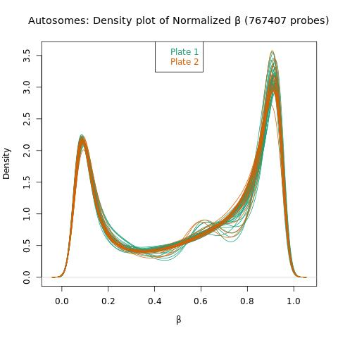

```r
knitr::include_graphics(paste0(fig_ext, 'normBeta_auto_MSC.jpg'))
```

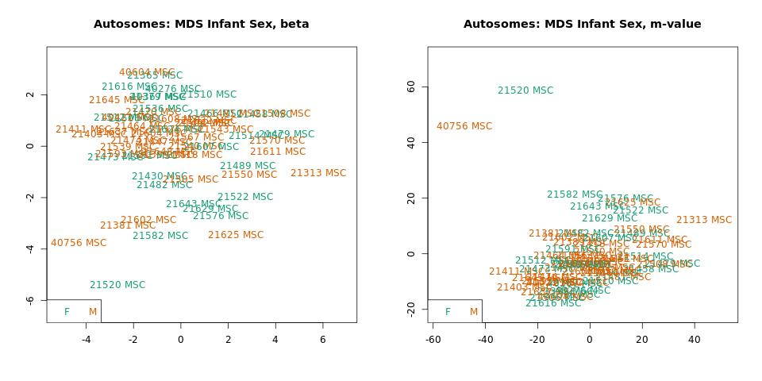

```r
knitr::include_graphics(paste0(fig_ext, 'mds_infantSex_auto_MSC.jpg'))
```

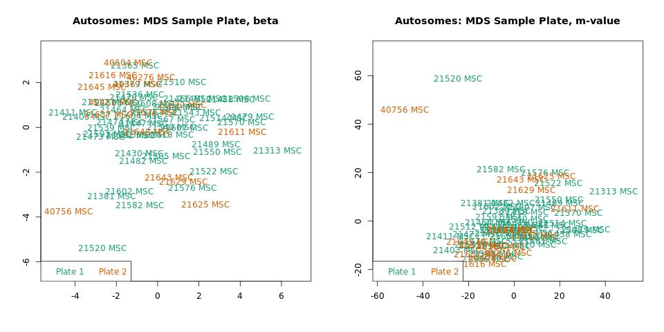

```r
knitr::include_graphics(paste0(fig_ext, 'mds_samplePlate_auto_MSC.jpg'))
```

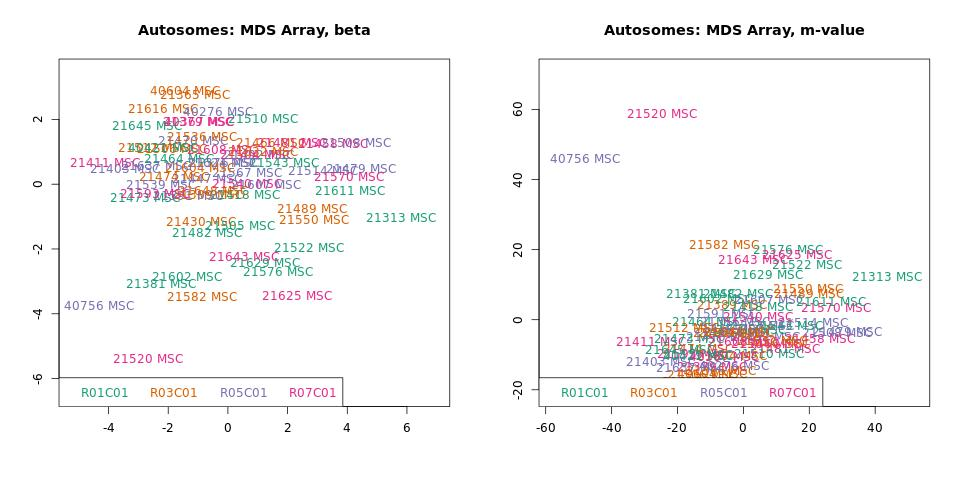

```r
knitr::include_graphics(paste0(fig_ext, 'mds_array_auto_MSC.jpg'))
```

There seems to be a sex effect in the data that will be taken care of by including offspring sex in the models for this data.

### Batch Correction

```r
batch_cor <- function(gset_norm, beta_norm, m_norm, tissue){
  mod <- model.matrix(~1, data = pData(gset_norm))

  # by Plate
  m_norm_plate <- ComBat(m_norm, gset_norm$Sample_Plate, mod, par.prior = TRUE, prior.plots = FALSE)
  colnames(m_norm_plate) <- sampleNames(gset_norm)
  beta_norm_plate <- lumi::m2beta(m_norm_plate)

  getPalette <- colorRampPalette(brewer.pal(8, "Dark2"))

  # plot Plate
  ncolor <- length(unique(pData(gset_norm)$Sample_Plate))
  jpeg(paste0(fig_ext, "mds_normPlate_", tissue, ".jpg"), width = 960)
  par(cex = 0.4, mfrow = c(1,2))
  mdsPlot(beta_norm_plate, numPositions = 1000, sampGroups = pData(gset_norm)$Sample_Plate,
          sampNames = pData(gset_norm)$Sample_Name, pal = getPalette(ncolor),
          main = "Whole Genome, Plate Corrected: MDS Plate, beta values")
  mdsPlot(m_norm_plate, numPositions = 1000, sampGroups = pData(gset_norm)$Sample_Plate,
          sampNames = pData(gset_norm)$Sample_Name, pal = getPalette(ncolor),
          main = "Whole Genome, Plate Corrected: MDS Plate, m-values")
  invisible(dev.off())

  out <- list(beta_norm_plate, m_norm_plate)
  names(out) <- c("beta", "m")
  return(out)
}

end_PLC <- batch_cor(norm_PLC$gset, norm_PLC$beta, norm_PLC$mset, "PLC")
end_MSC <- batch_cor(norm_MSC$gset, norm_MSC$beta, norm_MSC$mset, "MSC")
```

**PLC: Whole Genome by Sample Plate, after quantile normalization and batch correction for sample plate**

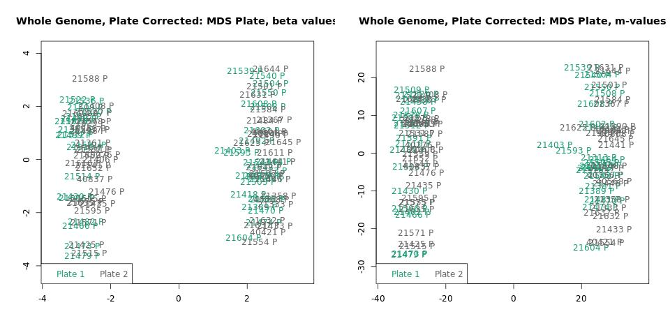

```r
knitr::include_graphics(paste0(fig_ext, 'mds_normPlate_PLC.jpg'))
```

**MSC: Whole Genome by Sample Plate, after quantile normalization and batch correction for sample plate**

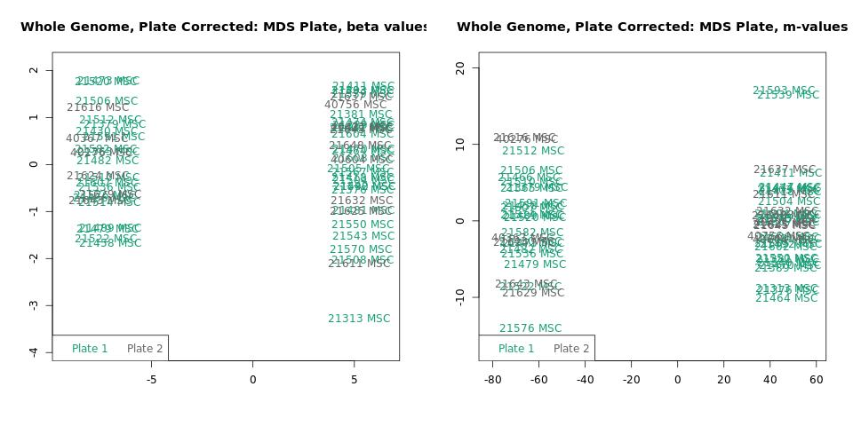

```r
knitr::include_graphics(paste0(fig_ext, 'mds_normPlate_MSC.jpg'))
```

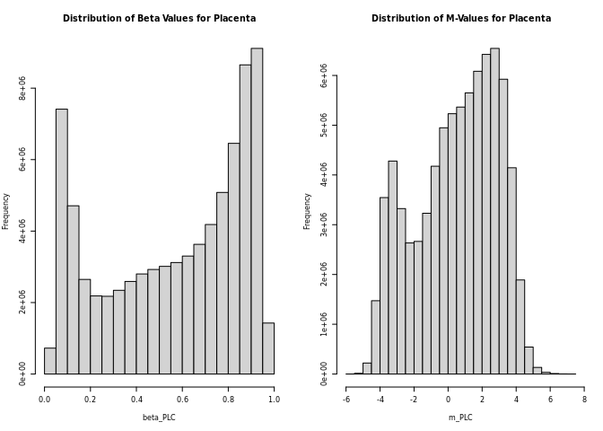

```r
# save out the data
samp.names <- colnames(end_PLC$m)
cpg <- row.names(end_PLC$m)

m_PLC <- t(end_PLC$m)
fwrite(m_PLC, file = paste0(dir_ext, "PLC_m_norm_batch_plate.csv"), row.names = TRUE, col.names = TRUE)

m_MSC <- t(end_MSC$m)
fwrite(m_MSC, file = paste0(dir_ext, "MSC_m_norm_batch_plate.csv"), row.names = TRUE, col.names = TRUE)

beta_PLC <- t(end_PLC$beta)
beta_MSC <- t(end_MSC$beta)

par(mfrow = c(1,2), cex = 0.5)
hist(beta_PLC, main = "Distribution of Beta Values for Placenta")
hist(m_PLC, main = "Distribution of M-Values for Placenta")
```

```r
min(beta_PLC)
```

```
## [1] 0.01564144
```

```r
max(beta_PLC)
```

```
## [1] 0.9936908
```

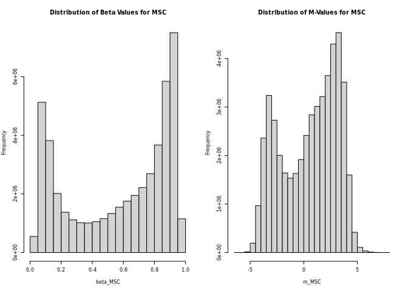

```r
par(mfrow = c(1,2), cex = 0.5)
hist(beta_MSC, main = "Distribution of Beta Values for MSC")
hist(m_MSC, main = "Distribution of M-Values for MSC")
```

```r
min(beta_MSC)
```

```
## [1] 0.01516269
```

```r
max(beta_MSC)
```

```
## [1] 0.9959432
```